# Assignment 2(1-6)

Group 1

2025-12-10

## 0.Data processing

```r
pacman::p_load(char = c(
  "tidyverse","rms","haven","mgcv","epitools",
  "geepack","skimr","pROC","tableone","emmeans","glmtoolbox", "rmda",
  "CalibrationCurves","dcurves", "MASS", "ggeffects", "ggplot2", "patchwork", "pROC"
), install = FALSE)
```

```r
set.seed(1234)
# read in the data
data("wcgs", package = "epitools")

# create factors from var ditpat0 with levels B and A in stead of 0 and 1
wcgs$dibpat0f <- factor(wcgs$dibpat0,
                        levels = 0:1,
                        labels = c("B", "A"))

# create categories for age
wcgs$agegroup <- cut(
  wcgs$age0,
  breaks = c(39, 45, 55, 60),
  include.lowest = TRUE,
  right = FALSE
)

# binary variable for smoker or not
wcgs$smoker <- ifelse(wcgs$ncigs0 > 0, 1, 0)
wcgs$smokerf <- factor(wcgs$smoker,
                       levels = c(0, 1),
                       labels = c("No", "Yes"))

# convert height from inches to cm
wcgs$heightcm <- wcgs$height0 * 2.54
wcgs$weightkg <- wcgs$weight0 * 0.45359237

wcgs$bmi <- wcgs$weightkg / (wcgs$heightcm / 100)^2
wcgs$bmicat <- cut(
  wcgs$bmi,
  breaks = c(0, 25, 30, 40),
  include.lowest = TRUE,
  right = FALSE
)


wcgs$cholmmol <- wcgs$chol0 / 39
wcgs$cholmmol <- ifelse(wcgs$cholmmol < 15, wcgs$cholmmol, NA)
wcgs$sbp10 <- wcgs$sbp0 / 10

# Create categories of sbp (systolic blood pressure). Make sure to have the lowest and highest
wcgs$sbpcat <- cut(
  wcgs$sbp0,
  breaks = c(0, 140, 240),
  include.lowest = TRUE,
  right = FALSE
)

# For use when tabulating the data you can create labels
wcgs$chd69f <- factor(
  wcgs$chd69,
  levels = c(0, 1),
  labels = c("No", "Yes")
)


wcgs$arcus0f <- factor(
  wcgs$arcus0,
  levels = c(0, 1),
  labels = c("No", "Yes")
)

d <- wcgs %>%
  dplyr::select(
    id,
    agegroup,
    age0,
    cholmmol,
    sbp10,
    bmi,
    bmicat,
    smokerf,
    arcus0,
    arcus0f,
    dibpat0f,
    chd69,
    chd69f
  )

## complete case
dc <- d %>% drop_na()

nrow(d)
```

```
## [1] 3154
```

```r
nrow(dc)
```

```
## [1] 3139
```

```r
sapply(dc, class)
```

```
##        id  agegroup      age0  cholmmol     sbp10       bmi    bmicat   smokerf
## "integer"  "factor" "integer" "numeric" "numeric" "numeric"  "factor"  "factor"
##    arcus0   arcus0f  dibpat0f     chd69    chd69f
## "integer"  "factor"  "factor" "integer"  "factor"
```

## 1. Table 1

```r
vars_cont <- c("age0", "sbp10", "cholmmol", "bmi")
vars_cat  <- c("agegroup", "smokerf", "arcus0f", "dibpat0f", "chd69f")

table1 <- CreateTableOne(
  vars       = c(vars_cont, vars_cat),
  data       = dc,
  factorVars = vars_cat
)

# print Table 1
print(table1, showAllLevels = TRUE, quote = FALSE, noSpaces = TRUE)
```

```
##
##                        level   Overall
##   n                            3139
##   age0 (mean (SD))             46.28 (5.52)
##   sbp10 (mean (SD))            12.86 (1.51)
##   cholmmol (mean (SD))         5.80 (1.10)
##   bmi (mean (SD))              24.52 (2.56)
##   agegroup (%)         [39,45) 1440 (45.9)
##                        [45,55) 1380 (44.0)
##                        [55,60] 319 (10.2)
##   smokerf (%)          No      1645 (52.4)
##                        Yes     1494 (47.6)
##   arcus0f (%)          No      2201 (70.1)
##                        Yes     938 (29.9)
##   dibpat0f (%)         B       1557 (49.6)
##                        A       1582 (50.4)
##   chd69f (%)           No      2885 (91.9)
##                        Yes     254 (8.1)
```

```r
summary(table1)
```

```
##
##      ### Summary of continuous variables ###
##
## strata: Overall
##             n miss p.miss mean sd median p25 p75 min max skew kurt
## age0     3139    0      0   46  6     45  42  50  39  59  0.5 -0.8
## sbp10    3139    0      0   13  2     13  12  14  10  23  1.2  2.6
## cholmmol 3139    0      0    6  1      6   5   6   3  11  0.4  0.5
## bmi      3139    0      0   25  3     24  23  26  11  39  0.5  2.0
##
## =======================================================================================
##
##      ### Summary of categorical variables ###
##
## strata: Overall
##       var    n miss p.miss   level freq percent cum.percent
##  agegroup 3139    0    0.0 [39,45) 1440    45.9        45.9
##                            [45,55) 1380    44.0        89.8
##                            [55,60]  319    10.2       100.0
##
##   smokerf 3139    0    0.0      No 1645    52.4        52.4
##                                Yes 1494    47.6       100.0
##
##   arcus0f 3139    0    0.0      No 2201    70.1        70.1
##                                Yes  938    29.9       100.0
##
##  dibpat0f 3139    0    0.0       B 1557    49.6        49.6
##                                  A 1582    50.4       100.0
##
##    chd69f 3139    0    0.0      No 2885    91.9        91.9
##                                Yes  254     8.1       100.0
##
```

## 2. Overall risk or overall rate(Need to be checked)

1. The outcome of interest is the presence of coronary heart disease (CHD), represented by the binary variable ‘chd69’.

Age — risk increases with older age;

Systolic blood pressure (sbp10) — higher blood pressure increases CHD risk;

Serum cholesterol (cholmmol) — elevated cholesterol is a well-established risk factor;

Body mass index (bmi) — overweight and obesity are associated with higher CHD risk;

Smoking (smokerf) — current smokers have increased CHD incidence;

Corneal arcus (arcus0f) — a possible visual indicator of lipid abnormalities.

```r
# (c)
n_total <- nrow(d)
n_total
```

```
## [1] 3154
```

```r
n_total_no_na <- nrow(dc)
n_total_no_na
```

```
## [1] 3139
```

```r
# (d) overall prevalence of the disease
prev_chd <- mean(dc$chd69 == 1)
prev_chd
```

```
## [1] 0.08091749
```

## 3. Building the model and choosing predictors

### (a)

```r
# We start with a full model: all known risk factors.
# chd69: 0/1;
# predictors：age0, sbp10, cholmmol, bmi, smokerf, arcus0f, dibpat0f

dc$chd69 <- as.factor(dc$chd69)
mod_full <- glm(
  chd69 ~ age0 + sbp10 + cholmmol + bmi +
    smokerf + arcus0f + dibpat0f,
  data   = dc,
  family = binomial(link = "logit")
)

summary(mod_full)
```

```
##
## Call:
## glm(formula = chd69 ~ age0 + sbp10 + cholmmol + bmi + smokerf +
##     arcus0f + dibpat0f, family = binomial(link = "logit"), data = dc)
##
## Coefficients:
##              Estimate Std. Error z value Pr(>|z|)
## (Intercept) -12.24944    0.98648 -12.417  < 2e-16 ***
## age0          0.05725    0.01226   4.669 3.03e-06 ***
## sbp10         0.18205    0.04156   4.380 1.18e-05 ***
## cholmmol      0.40142    0.06004   6.686 2.30e-11 ***
## bmi           0.05928    0.02659   2.229   0.0258 *
## smokerfYes    0.60023    0.14191   4.230 2.34e-05 ***
## arcus0fYes    0.22038    0.14340   1.537   0.1243
## dibpat0fA     0.70145    0.14510   4.834 1.34e-06 ***
## ---
## Signif. codes:  0 '***' 0.001 '**' 0.01 '*' 0.05 '.' 0.1 ' ' 1
##
## (Dispersion parameter for binomial family taken to be 1)
##
##     Null deviance: 1764.1  on 3138  degrees of freedom
## Residual deviance: 1578.2  on 3131  degrees of freedom
## AIC: 1594.2
##
## Number of Fisher Scoring iterations: 6
```

```r
mod_step <- stepAIC(mod_full, direction = "both", trace = TRUE)
```

```
## Start:  AIC=1594.23
## chd69 ~ age0 + sbp10 + cholmmol + bmi + smokerf + arcus0f + dibpat0f
##
##            Df Deviance    AIC
## <none>          1578.2 1594.2
## - arcus0f   1   1580.6 1594.6
## - bmi       1   1583.1 1597.1
## - sbp10     1   1596.5 1610.5
## - smokerf   1   1596.6 1610.6
## - age0      1   1599.9 1613.9
## - dibpat0f  1   1602.9 1616.9
## - cholmmol  1   1622.6 1636.6
```

```r
# Compare AIC
AIC(mod_full, mod_step)
```

```
##          df      AIC
## mod_full  8 1594.227
## mod_step  8 1594.227
```

Using the AIC criterion, all main variables were preserved.

### (b)

#### Categorical Variables

```r
# ---- 1. Create BMI group variables ----
# train_data$bmigroup <- cut(
#   train_data$bmi,
#   breaks = c(-Inf, 18.5, 25, 30, Inf),
#   labels = c("Underweight", "Normal", "Overweight", "Obese")
# )

# categorical bmi is loaded as bmicat

# ---- 2. Four Models ----
m1 <- glm(chd69 ~ age0 + sbp10 + cholmmol + bmi + smokerf + arcus0f + dibpat0f,
          data = dc, family = binomial)    # baseline

m2 <- glm(chd69 ~ agegroup + sbp10 + cholmmol + bmi + smokerf + arcus0f + dibpat0f,
          data = dc, family = binomial)    # age categorical

m3 <- glm(chd69 ~ age0 + sbp10 + cholmmol + bmicat + smokerf + arcus0f + dibpat0f,
          data = dc, family = binomial)    # BMI categorical

m4 <- glm(chd69 ~ agegroup + sbp10 + cholmmol + bmicat + smokerf + arcus0f + dibpat0f,
          data = dc, family = binomial)    # both categorical

# ---- 3. Model Comparison ----
AIC(m1, m2, m3, m4)
```

```
##    df      AIC
## m1  8 1594.227
## m2  9 1596.895
## m3  9 1598.766
## m4 10 1601.420
```

```r
anova(m1, m2, test = "LRT")  # Comparing Continuous Age vs. agegroup
```

```
## Analysis of Deviance Table
##
## Model 1: chd69 ~ age0 + sbp10 + cholmmol + bmi + smokerf + arcus0f + dibpat0f
## Model 2: chd69 ~ agegroup + sbp10 + cholmmol + bmi + smokerf + arcus0f +
##     dibpat0f
##   Resid. Df Resid. Dev Df Deviance Pr(>Chi)
## 1      3131     1578.2
## 2      3130     1578.9  1 -0.66814
```

```r
anova(m1, m3, test = "LRT")  # Comparison of Continuous vs. Grouped BMI
```

```
## Analysis of Deviance Table
##
## Model 1: chd69 ~ age0 + sbp10 + cholmmol + bmi + smokerf + arcus0f + dibpat0f
## Model 2: chd69 ~ age0 + sbp10 + cholmmol + bmicat + smokerf + arcus0f +
##     dibpat0f
##   Resid. Df Resid. Dev Df Deviance Pr(>Chi)
## 1      3131     1578.2
## 2      3130     1580.8  1  -2.5393
```

#### Interaction Terms

```r
# ---- 1. Age × Smoking ----
m_age_smoke <- glm(chd69 ~ age0 * smokerf + sbp10 + cholmmol + bmi + arcus0f + dibpat0f,
                   data = dc, family = binomial)
p1 <- ggpredict(m_age_smoke, terms = c("age0", "smokerf"))
```

```
## Data were 'prettified'. Consider using `terms="age0 [all]"` to get
##   smooth plots.
```

```r
g1 <- plot(p1) +
  labs(title = "Age × Smoking",
       x = "Age", y = "Predicted probability") +
  theme_minimal() +
  theme(legend.position = "bottom")

# ---- 2. Cholesterol × BMI ----
m_chol_bp <- glm(chd69 ~ cholmmol * bmi + age0 + smokerf + sbp10 + arcus0f + dibpat0f,
                 data = dc, family = binomial)
p2 <- ggpredict(m_chol_bp, terms = c("bmi", "cholmmol [quantile]"))
```

```
## Data were 'prettified'. Consider using `terms="bmi [all]"` to get smooth
##   plots.
```

```r
p2$group <- factor(round(as.numeric(as.character(p2$group)), 1))

g2 <- plot(p2) +
  labs(title = "Cholesterol × BMI",
       x = "BMI", y = "Predicted probability") +
  theme_minimal() +
  theme(legend.position = "bottom")

# ---- 3. Age × Arcus ----
m_age_arcus <- glm(
  chd69 ~ age0 * arcus0f + sbp10 + cholmmol + smokerf + bmi + dibpat0f,
  data = dc, family = binomial
)

p3 <- ggpredict(m_age_arcus, terms = c("age0", "arcus0f"))
```

```
## Data were 'prettified'. Consider using `terms="age0 [all]"` to get
##   smooth plots.
```

```r
g3 <- plot(p3) +
  labs(
    title = "Age × Arcus",
    x = "Age",
    y = "Predicted probability",
    color = "Arcus (0 = No, 1 = Yes)"
  ) +
  theme_minimal() +
  theme(legend.position = "bottom")


# ---- 4. Smoking × Blood pressure ----
m_smoke_bp <- glm(chd69 ~ smokerf * sbp10 + age0 + cholmmol + bmi + arcus0f + dibpat0f,
                  data = dc, family = binomial)
p4 <- ggpredict(m_smoke_bp, terms = c("sbp10", "smokerf"))
```

```
## Data were 'prettified'. Consider using `terms="sbp10 [all]"` to get
##   smooth plots.
```

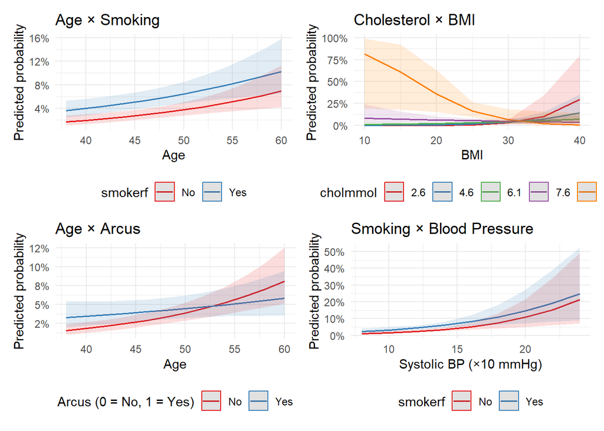

```r
g4 <- plot(p4) +
  labs(title = "Smoking × Blood Pressure",
       x = "Systolic BP (×10 mmHg)", y = "Predicted probability") +
  theme_minimal() +
  theme(legend.position = "bottom")

# ---- Combine into 2×2 grid ----
(g1 + g2) / (g3 + g4)
```

The plots show that the relationships for age × smoking and smoking × blood pressure are approximately parallel, indicating no meaningful interaction effects. In contrast, the curves for cholesterol × BMI and age × arcus are clearly non-parallel, suggesting potential interactions between these variables in influencing CHD risk.

##### Try all interactions and test for significance.

```r
#  Define the main effects model
m_main <- glm(
  chd69 ~ age0 + sbp10 + cholmmol + bmi + smokerf + arcus0f + dibpat0f,
  data = dc,
  family = binomial
)

# All candidate interaction combinations
vars <- c("age0", "sbp10", "cholmmol", "bmi", "smokerf", "arcus0f", "dibpat0f")
interactions <- combn(vars, 2, simplify = FALSE)

results <- data.frame(
  Interaction = character(),
  Df = numeric(),
  Deviance = numeric(),
  P_value = numeric(),
  stringsAsFactors = FALSE
)

# Iteratively test each interaction term
for (pair in interactions) {
  formula_int <- as.formula(
    paste("chd69 ~", paste(vars, collapse = " + "), "+", paste(pair, collapse = ":"))
  )

  m_int <- glm(formula_int, data = dc, family = binomial)

  lrt <- anova(m_main, m_int, test = "LRT")

  res_row <- data.frame(
    Interaction = paste(pair, collapse = ":"),
    Df = lrt$Df[2],
    Deviance = round(lrt$Deviance[2], 3),
    P_value = round(lrt$`Pr(>Chi)`[2], 5)
  )

  results <- rbind(results, res_row)
}

results <- results[order(results$P_value), ]
rownames(results) <- NULL
results
```

```
##          Interaction Df Deviance P_value
## 1       cholmmol:bmi  1    7.921 0.00489
## 2       age0:arcus0f  1    4.285 0.03845
## 3          sbp10:bmi  1    3.544 0.05976
## 4      sbp10:arcus0f  1    2.800 0.09424
## 5  cholmmol:dibpat0f  1    2.048 0.15237
## 6      age0:cholmmol  1    1.969 0.16055
## 7   cholmmol:smokerf  1    1.913 0.16660
## 8   arcus0f:dibpat0f  1    1.600 0.20584
## 9         age0:sbp10  1    1.439 0.23024
## 10          age0:bmi  1    1.395 0.23758
## 11    sbp10:dibpat0f  1    1.289 0.25625
## 12       bmi:smokerf  1    1.060 0.30321
## 13  smokerf:dibpat0f  1    0.942 0.33185
## 14    sbp10:cholmmol  1    0.904 0.34182
## 15     age0:dibpat0f  1    0.738 0.39033
## 16      age0:smokerf  1    0.397 0.52865
## 17     sbp10:smokerf  1    0.231 0.63047
## 18  cholmmol:arcus0f  1    0.104 0.74707
## 19   smokerf:arcus0f  1    0.014 0.90510
## 20      bmi:dibpat0f  1    0.011 0.91664
## 21       bmi:arcus0f  1    0.007 0.93296
```

Likelihood ratio tests for all pairwise interactions showed that cholesterol × BMI (p = 0.0049) and age × arcus (p = 0.0385) significantly improved model fit, suggesting that the effects of cholesterol on CHD risk vary with BMI, and that the influence of age differs depending on the presence of corneal arcus. Other tested interactions were not significant (p > 0.05) and were not included in the final model.

```r
m_no_int <- glm(chd69 ~ age0 + sbp10 + cholmmol + bmi + smokerf + arcus0f + dibpat0f,
                family = binomial, data = dc)

m_final <- glm(
  chd69 ~ age0 + sbp10 + cholmmol*bmi + age0*arcus0f + smokerf + dibpat0f,
  data = dc,
  family = binomial
)
summary(m_final)
```

```
##
## Call:
## glm(formula = chd69 ~ age0 + sbp10 + cholmmol * bmi + age0 *
##     arcus0f + smokerf + dibpat0f, family = binomial, data = dc)
##
## Coefficients:
##                  Estimate Std. Error z value Pr(>|z|)
## (Intercept)     -22.24589    3.35124  -6.638 3.18e-11 ***
## age0              0.07711    0.01583   4.873 1.10e-06 ***
## sbp10             0.18462    0.04155   4.443 8.87e-06 ***
## cholmmol          1.87607    0.51971   3.610 0.000306 ***
## bmi               0.41941    0.12813   3.273 0.001063 **
## arcus0fYes        2.66054    1.18943   2.237 0.025298 *
## smokerfYes        0.60012    0.14221   4.220 2.44e-05 ***
## dibpat0fA         0.71865    0.14573   4.931 8.17e-07 ***
## cholmmol:bmi     -0.05900    0.02067  -2.855 0.004308 **
## age0:arcus0fYes  -0.05029    0.02438  -2.062 0.039161 *
## ---
## Signif. codes:  0 '***' 0.001 '**' 0.01 '*' 0.05 '.' 0.1 ' ' 1
##
## (Dispersion parameter for binomial family taken to be 1)
##
##     Null deviance: 1764.1  on 3138  degrees of freedom
## Residual deviance: 1566.1  on 3129  degrees of freedom
## AIC: 1586.1
##
## Number of Fisher Scoring iterations: 6
```

```r
anova(m_no_int, m_final, test = "LRT")
```

```
## Analysis of Deviance Table
##
## Model 1: chd69 ~ age0 + sbp10 + cholmmol + bmi + smokerf + arcus0f + dibpat0f
## Model 2: chd69 ~ age0 + sbp10 + cholmmol * bmi + age0 * arcus0f + smokerf +
##     dibpat0f
##   Resid. Df Resid. Dev Df Deviance Pr(>Chi)
## 1      3131     1578.2
## 2      3129     1566.1  2   12.156 0.002292 **
## ---
## Signif. codes:  0 '***' 0.001 '**' 0.01 '*' 0.05 '.' 0.1 ' ' 1
```

```r
AIC(m_no_int, m_final)
```

```
##          df      AIC
## m_no_int  8 1594.227
## m_final  10 1586.071
```

```r
# roc_main <- roc(dc$chd69, fitted(m_no_int))
# roc_final <- roc(dc$chd69, fitted(m_final))
# auc(roc_main); auc(roc_final)
```

Interaction terms were included because adding cholmmol × bmi and age0 × arcus0f significantly improved model fit ($\Delta$Deviance = 12.16, p = 0.0023) and reduced AIC from 1594.2 to 1586.1. These results indicate that the effects of cholesterol on CHD risk vary with BMI, and that the impact of age may differ depending on the presence of corneal arcus.

## (c)

```r
# Calculate each person's predicted risk
dc$pred_risk <- predict(m_final, type = "response")
```

```r
predicted_class <- ifelse(dc$pred_risk > 0.5, 1, 0)
accuracy <- mean(predicted_class == dc$chd69, na.rm = TRUE)
print(accuracy)
```

```
## [1] 0.9200382
```

## 4. Discrimination

### 4a

The final logistic regression model can be written as:

$$\text{logit}\left(P(\text{CHD}_{69}=1)\right) =
\beta_0 +
\beta_1 \cdot \text{age0} +
\beta_2 \cdot \text{sbp10} +
\beta_3 \cdot \text{cholmmol} +
\beta_4 \cdot \text{bmi} +
\beta_5 \cdot \text{smokerf} +
\beta_6 \cdot \text{arcus0f} +
\beta_7 \cdot \text{dibpat0f} +
\beta_8 \cdot (\text{cholmmol} \times \text{bmi}) +
\beta_9 \cdot (\text{age0} \times \text{arcus0f})$$

These two interactions, cholesterol × BMI and age × corneal arcus, improved the model fit based on the likelihood ratio test and resulted in a reduction in AIC.

```r
#4a
m_final
```

```
##
## Call:  glm(formula = chd69 ~ age0 + sbp10 + cholmmol * bmi + age0 *
##     arcus0f + smokerf + dibpat0f, family = binomial, data = dc)
##
## Coefficients:
##     (Intercept)             age0            sbp10         cholmmol
##       -22.24589          0.07711          0.18462          1.87607
##             bmi       arcus0fYes       smokerfYes        dibpat0fA
##         0.41941          2.66054          0.60012          0.71865
##    cholmmol:bmi  age0:arcus0fYes
##        -0.05900         -0.05029
##
## Degrees of Freedom: 3138 Total (i.e. Null);  3129 Residual
## Null Deviance:       1764
## Residual Deviance: 1566  AIC: 1586
```

```r
roc_final <- roc(dc$chd69, dc$pred_risk)
```

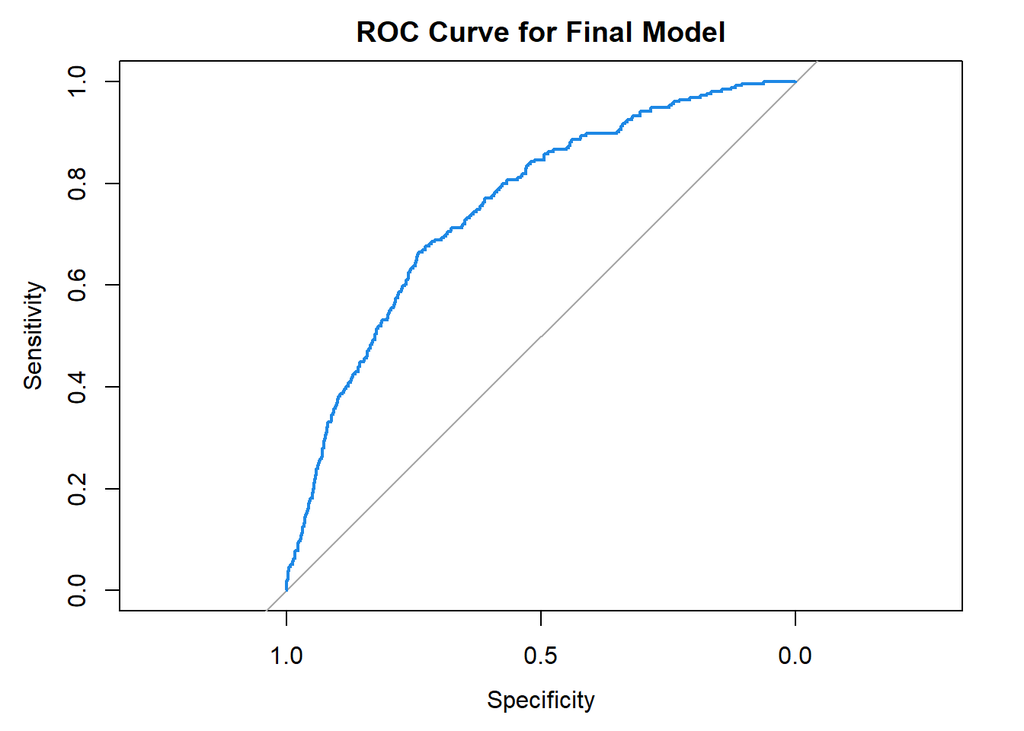

```r
plot(roc_final,
     col  = "#1E88E5",
     lwd  = 2,
     main = "ROC Curve for Final Model",
     xlim=c(1.0, 0.0),
     ylim=c(0.0, 1.0))
```

```r
auc_value    <- auc(roc_final)
ci_auc_value <- ci.auc(roc_final)

auc_value
```

```
## Area under the curve: 0.7543
```

```r
ci_auc_value
```

```
## 95% CI: 0.7246-0.7839 (DeLong)
```

A ROC curve is shown in Figure ROC Curve (blue line). The model demonstrates a moderate ability to discriminate between CHD cases and non-cases, AUC was estimated as 0.7543, and 95% CI: 0.7246–0.7839.

### 4b

```r
#4b

coords_best <- coords(
  roc_final,
  x = "best",
  best.method = "youden",
  ret = c("threshold", "sensitivity", "specificity")
)

coords_best
```

```
##    threshold sensitivity specificity
## 1 0.09582262   0.6653543   0.7403813
```

CHD is relatively rare in this dataset with about 8 percent of individuals diagnosed. Even with this imbalance the model still shows solid discrimination ability. Based on Youden’s Index: $y = sensitivity + specificity - 1$, the optimal cutoff is approximately 0.10. At this threshold the model achieves a sensitivity of about 0.67 and a specificity of about 0.74.

### 4c

To adjust for optimism in the predictions, we can use the bootstrapping method using 200 repetitions.

```r
Bootstrap_iterations <- 200
auc_boot <- numeric(Bootstrap_iterations)
auc_orig <- auc(roc_final)

for (i in 1:Bootstrap_iterations) {
  # bootstrap sample
  idx <- sample(1:nrow(dc), replace = TRUE)
  boot_data <- dc[idx, ]

  # fit same model
  boot_model <- glm(
    chd69 ~ age0 + sbp10 + cholmmol*bmi + age0*arcus0f + smokerf + dibpat0f,
    data = boot_data,
    family = binomial
  )

  # Suppress Messages is used here to prevent spam
  # messages from the roc function.
 boot_roc <- suppressMessages(
    roc(boot_data$chd69, fitted(boot_model))
  )

  auc_boot[i] <- auc(boot_roc)
}


auc_adj <- mean(auc_boot)
ci_boot <- quantile(auc_boot, probs = c(0.025, 0.975))

auc_orig
```

```
## Area under the curve: 0.7543
```

```r
auc_adj
```

```
## [1] 0.759566
```

```r
ci_boot
```

```
##      2.5%     97.5%
## 0.7317410 0.7848962
```

### 4d

```r
K <- 10
folds <- sample(rep(1:K, length.out = nrow(dc)))

auc_cv <- numeric(K)

for (k in 1:K) {
  # Training and testing split
  test_idx <- which(folds == k)
  train_data <- dc[-test_idx, ]
  test_data  <- dc[test_idx, ]

  # Fit the same final model structure
  m_cv <- glm(chd69 ~ age0 + sbp10 + cholmmol*bmi + age0*arcus0f + smokerf + dibpat0f,
              data = train_data,
              family = binomial)

  # Predict on test fold
  pred_prob <- predict(m_cv, newdata = test_data, type = "response")

  # Save fold AUC
  auc_cv[k] <- suppressMessages(auc(roc(test_data$chd69, pred_prob)))
}

auc_cv_mean <- mean(auc_cv)
auc_cv_ci <- quantile(auc_cv,
                      probs = c(0.025, 0.975))

auc_cv_mean
```

```
## [1] 0.7455776
```

```r
auc_cv_ci
```

```
##      2.5%     97.5%
## 0.6793982 0.8030823
```

To further validate model generalizability, we performed 10-fold cross-validation, obtaining:

Using 10-fold cross-validation, the model reached a mean AUC of 0.74 with a 95% confidence interval of 0.68 to 0.80. The results are consistent with the original and bootstrap-adjusted AUC estimates, so the model seems to perform similarly on new data.

## 5.Calibration

### 5a

A useful page to understand calibration process: https://cran.r-project.org/web/packages/CalibrationCurves/vignettes/CalibrationCurves.html

```r
# plot calibration curve
summary(m_final)
```

```
##
## Call:
## glm(formula = chd69 ~ age0 + sbp10 + cholmmol * bmi + age0 *
##     arcus0f + smokerf + dibpat0f, family = binomial, data = dc)
##
## Coefficients:
##                  Estimate Std. Error z value Pr(>|z|)
## (Intercept)     -22.24589    3.35124  -6.638 3.18e-11 ***
## age0              0.07711    0.01583   4.873 1.10e-06 ***
## sbp10             0.18462    0.04155   4.443 8.87e-06 ***
## cholmmol          1.87607    0.51971   3.610 0.000306 ***
## bmi               0.41941    0.12813   3.273 0.001063 **
## arcus0fYes        2.66054    1.18943   2.237 0.025298 *
## smokerfYes        0.60012    0.14221   4.220 2.44e-05 ***
## dibpat0fA         0.71865    0.14573   4.931 8.17e-07 ***
## cholmmol:bmi     -0.05900    0.02067  -2.855 0.004308 **
## age0:arcus0fYes  -0.05029    0.02438  -2.062 0.039161 *
## ---
## Signif. codes:  0 '***' 0.001 '**' 0.01 '*' 0.05 '.' 0.1 ' ' 1
##
## (Dispersion parameter for binomial family taken to be 1)
##
##     Null deviance: 1764.1  on 3138  degrees of freedom
## Residual deviance: 1566.1  on 3129  degrees of freedom
## AIC: 1586.1
##
## Number of Fisher Scoring iterations: 6
```

```r
calibration_data <- data.frame(
  Actual = as.integer(dc$chd69)-1,
  Predicted_Prob = dc$pred_risk
)
head(calibration_data)
```

```
##   Actual Predicted_Prob
## 1      0    0.061212784
## 2      0    0.091036968
## 3      0    0.007928205
## 4      0    0.008433894
## 5      1    0.147622220
## 6      0    0.034148447
```

```r
calPerf <- val.prob.ci.2(calibration_data$Predicted_Prob, calibration_data$Actual,logistic.cal = TRUE, col.log = "orange")
```

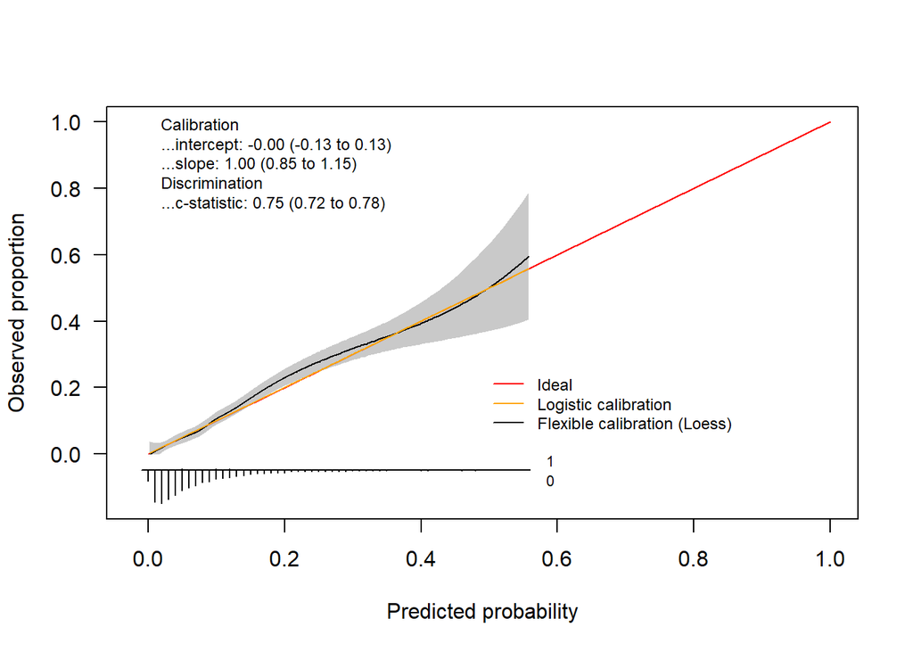

```r
calPerf
```

```
## Call:
## val.prob.ci.2(p = calibration_data$Predicted_Prob, y = calibration_data$Actual,
##     logistic.cal = TRUE, col.log = "orange")
##
## A 95% confidence interval is given for the calibration intercept, calibration slope and c-statistic.
##
##           Dxy       C (ROC)            R2             D      D:Chi-sq
##  5.085250e-01  7.542625e-01  1.422342e-01  6.278289e-02  1.980755e+02
##           D:p             U      U:Chi-sq           U:p             Q
##  0.000000e+00 -6.371456e-04  0.000000e+00  1.000000e+00  6.342003e-02
##         Brier     Intercept         Slope          Emax  Brier scaled
##  6.924332e-02 -1.136358e-12  1.000000e+00  2.267075e-13  6.893285e-02
##          Eavg           ECI
##  6.168767e-03  1.029198e-02
```

By observing the CalibrationCurve object calPerf, we can extract the slope and intercept of the calibration model. The slope is 1 and the corresponding intercept is -1.136358e-12, which is extremely small and effectively zero. This indicates that the curve lies very close to the line y = x, demonstrating excellent calibration performance.

### 5b

```r
hltest(m_final)
```

```
##
##    The Hosmer-Lemeshow goodness-of-fit test
##
##  Group Size Observed  Expected
##      1  314        2  3.416937
##      2  314        7  6.380764
##      3  314        8  9.142095
##      4  314       12 12.169552
##      5  314       14 15.867890
##      6  314       22 20.367894
##      7  314       19 26.112871
##      8  314       43 34.046685
##      9  314       46 46.278524
##     10  313       81 80.216787
##
##          Statistic =  5.9425
## degrees of freedom =  8
##            p-value =  0.65367
```

Interpretation: H0 of Hosmer and Lemeshow method is that the model fits the data well. And here we can see the p-value of HL test is 0.65367, meaning that we can’t reject the null hypothesis. It suggests that there is no evidence of poor fit, i.e., our model is well-calibrated.

### 5c

```r
# building model only using "ageroup"
dc$chd69 <- as.factor(dc$chd69)
m_agegroup <- glm(chd69 ~ agegroup,
                      family = binomial,
                      data = dc)

summary(m_agegroup)
```

```
##
## Call:
## glm(formula = chd69 ~ agegroup, family = binomial, data = dc)
##
## Coefficients:
##                 Estimate Std. Error z value Pr(>|z|)
## (Intercept)      -2.9444     0.1209 -24.353  < 2e-16 ***
## agegroup[45,55)   0.7310     0.1509   4.844 1.27e-06 ***
## agegroup[55,60]   1.1636     0.2001   5.817 6.01e-09 ***
## ---
## Signif. codes:  0 '***' 0.001 '**' 0.01 '*' 0.05 '.' 0.1 ' ' 1
##
## (Dispersion parameter for binomial family taken to be 1)
##
##     Null deviance: 1764.1  on 3138  degrees of freedom
## Residual deviance: 1723.3  on 3136  degrees of freedom
## AIC: 1729.3
##
## Number of Fisher Scoring iterations: 5
```

```r
ma_pre_pro <- predict(m_agegroup, type = "response")
roc_ma <- roc(dc$chd69, ma_pre_pro)
auc(roc_ma)
```

```
## Area under the curve: 0.6091
```

### 5d

In order to compare two discrimination statistics between two models on the same data, we take the DeLong test. The null hypothesis of Delong test is that AUCs of two models do not differ significantly, that is $AUC_{1}$=$AUC_{2}$.

```r
Delong_result <- roc.test(roc_final, roc_ma, method = "delong")
print(Delong_result)
```

```
##
##  DeLong's test for two correlated ROC curves
##
## data:  roc_final and roc_ma
## Z = 8.4755, p-value < 2.2e-16
## alternative hypothesis: true difference in AUC is not equal to 0
## 95 percent confidence interval:
##  0.1116182 0.1787706
## sample estimates:
## AUC of roc1 AUC of roc2
##   0.7542625   0.6090681
```

We can see that p-value <2.2e-16< 0.05, we reject H0,showing that the fitting performance of the model constructed in question 3(“m_final”) is much better than that of the model including only the agegroup(“m_agegroup”).

### 5e

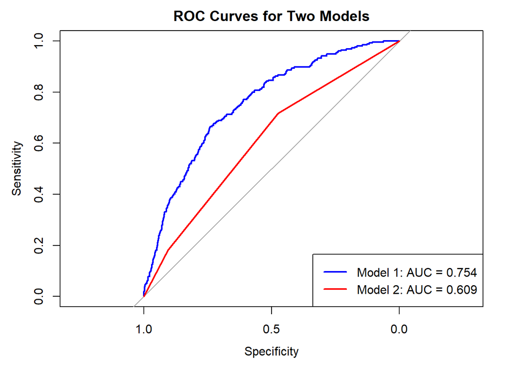

```r
# Plot ROC for Model 1
plot(roc_final,
     col = "blue",
     lwd = 2,
     main = "ROC Curves for Two Models")

# Add ROC for Model 2
plot(roc_ma,
     col = "red",
     lwd = 2,
     add = TRUE)

# Add legend
legend("bottomright",
       legend = c(
         paste("Model 1: AUC =", round(auc(roc_final), 3)),
         paste("Model 2: AUC =", round(auc(roc_ma), 3))
       ),
       col = c("blue", "red"),
       lwd = 2)
```

### 6a

```r
dc$chd69 <- as.numeric(as.character(dc$chd69))

dca_final <- decision_curve(
  chd69 ~ age0 + sbp10 + cholmmol*bmi + age0*arcus0f + smokerf + dibpat0f,
  data = dc,
  family = binomial,
  thresholds = seq(0, 0.3, by = 0.01),
  confidence.intervals = FALSE
)
```

```
## Note:  The data provided is used to both fit a prediction model and to estimate the respective decision curve. This may cause bias in decision curve estimates leading to over-confidence in model performance.
```

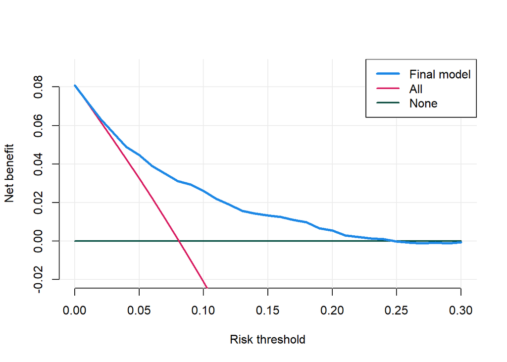

```r
plot_decision_curve(
  dca_final,
  curve.names        = c("Final model", "Treat all", "Treat none"),
  standardize        = FALSE,
  cost.benefit.axis  = FALSE,
  xlim               = c(0, 0.30),
  ylim               = c(-0.02, 0.09),
  xlab               = "Risk threshold",
  ylab               = "Net benefit",
  col                = c("#1E88E5","#D81B60","#004D40"),
  lwd                = c(3, 2, 2),
  lty                = c(1, 1, 1),
)
```

The decision curve shows that the final logistic regression model provides a higher net benefit than both default strategies (“Treat All” and “Treat None”) across a wide range of clinically relevant threshold probabilities. Specifically, the model yields a positive net benefit from very low thresholds up to approximately 0.25, indicating that it consistently outperforms treating all patients or treating none within this interval.

The benefit is greatest at low thresholds (around 0.08–0.15), where the model’s net benefit is clearly superior to both default strategies. As the threshold increases beyond 0.20–0.25, the model’s net benefit approaches the “Treat None” strategy and provides little additional value.

### 6b

The model is clinically useful, as its net benefit is higher than both the “Treat All” and “Treat None” strategies across thresholds from 0 to about 0.25. The model provides the largest improvement over the default strategies at lower thresholds, particularly around 0.10. Beyond approximately 0.20–0.25, its net benefit becomes similar to that of “Treat None,” indicating little additional clinical value at higher thresholds.

### 6c

```r
dca_final <- decision_curve(
  chd69 ~ age0 + sbp10 + cholmmol + bmi + smokerf + arcus0f + dibpat0f +
    cholmmol:bmi + age0:arcus0f,
  data       = dc,
  family     = binomial(link = "logit"),
  thresholds = seq(0, 0.30, by = 0.01),
  confidence.intervals = FALSE
)
```

```
## Note:  The data provided is used to both fit a prediction model and to estimate the respective decision curve. This may cause bias in decision curve estimates leading to over-confidence in model performance.
```

```
## Note: When multiple decision curves are plotted, decision curves for 'All' are calculated using the prevalence from the first DecisionCurve object in the list provided.
```

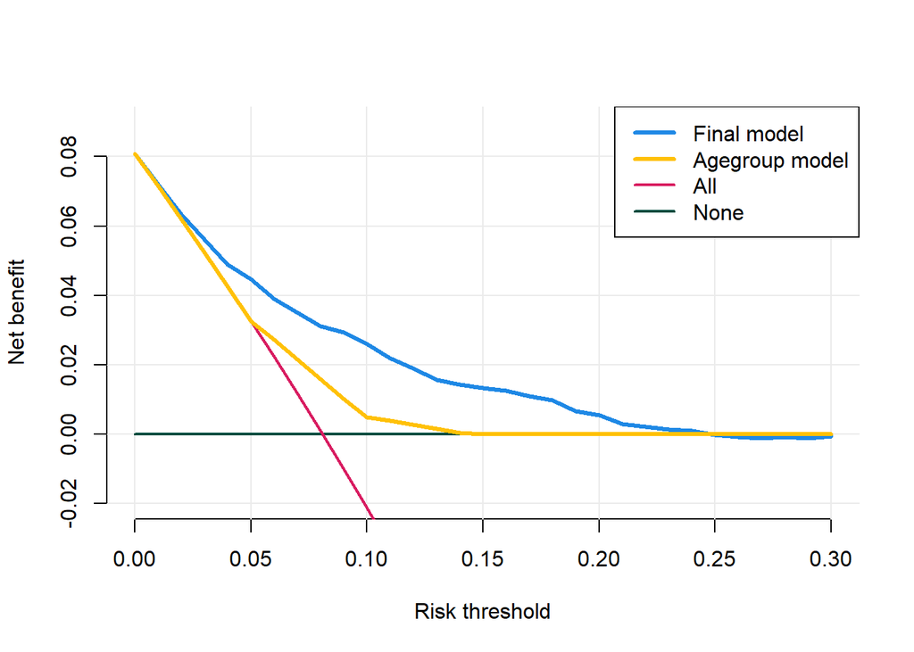

```r
dca_agegroup <- decision_curve(
  chd69 ~ agegroup,
  data       = dc,
  family     = binomial(link = "logit"),
  thresholds = seq(0, 0.30, by = 0.01),
  confidence.intervals = FALSE
)


plot_decision_curve(
  list(dca_final, dca_agegroup),
  curve.names        = c("Final model", "Agegroup model"),
  standardize        = FALSE,
  cost.benefit.axis  = FALSE,
  xlim               = c(0, 0.30),
  ylim               = c(-0.02, 0.09),
  xlab               = "Risk threshold",
  ylab               = "Net benefit",
  col                = c("#1E88E5","#FFC107", "#D81B60","#004D40"),
  lwd                = c(3, 3, 2, 2),
  lty                = c(1, 1, 1, 1),
)
```

Across nearly the entire threshold range (0–0.25), the final model shows higher net benefit than the agegroup model. The agegroup model’s net benefit drops quickly and becomes close to the “Treat None” strategy around 0.15, indicating limited usefulness. In contrast, the final model maintains positive net benefit up to about 0.25. Overall, the final model consistently provides greater clinical benefit than the simpler agegroup model.